# Network Security - Portscan

Network operators actively monitor their networks to protect against various intrusion attacks. Network attackers often perform random "portscans" of IP addresses to find vulnerable machines to compromise. Network Intrusion Detection Systems (NIDS) attempt to detect such behavior and flag these portscanners as malicious.

In this assignment, you will analyze the NetFlow network measurement data to identify potentially malicious traffic sent to the Princeton campus network. You will then simulate an online algorithm for identifying malicious remote hosts.

This notebook has several parts. Each part contains sections marked TODO that you need to complete.

**Put your name and netID in the cell below:**

**Name:姚凯文**

**NetId:10224507041**

### Parsing IPFIX Data

The `netflow.csv` file contains pre-processed netflow data from a Princeton campus network border router. The data is "unsampled," i.e. it compiles flow statistics for every packet that traverses any interface on the border router. We used the `nfdump` tool to process the raw NetFlow data that the router collected. Each row of the `netflow.csv` file, except for the header on top, logs the following information for a flow:

```
Date first seen, Time first seen (m:s), Date last seen, Time last seen (m:s), Duration (s), Protocol,
Src IP addr, Src port, Dst IP addr, Dst port, Packets, Bytes, Flags, Input interface, Output interface
```

To analyze this data, we first need to read it into a python data structure. The following code uses the built-in `csv` library to read `netflow.csv` into a list of dictionaries. The `csv` library documentation is here if you are interested: https://docs.python.org/2/library/csv.html

```python
import csv

with open('netflow.csv', 'r') as netflow_file:
    netflow_reader = csv.DictReader(netflow_file)
    netflow_data = list(netflow_reader)

print "Number of flow records: {}".format(len(netflow_data))
print
print "Sample flow entry: {}".format(netflow_data[0])
```

```
Number of flow records: 105360

Sample flow entry: {'Dst IP addr': '128.112.213.189', 'Protocol': 'ICMP', 'Bytes': '94', 'Src port': '0', 'Src IP addr': '172.16.241.1', 'Input interface': '120', 'Packets': '1', 'Date first seen': '10/29/15', 'Output interface': '0', 'Duration (s)': '0', 'Time first seen (m:s)': '04:48.9', 'Flags':…
```

## **Part A: TCP SYN Scan Detection**

In this part of the assignment, you will analyze TCP flow records to look for a TCP SYN scan attack. A [TCP SYN scan](https://en.wikipedia.org/wiki/Port_scanner#SYN_scanning) involves sending a TCP SYN packet to many different destinations to discover vulnerable machines on the network with open ports

### Background

In the previous assignment, we analyzed popular destinations by number of flows and by overall traffic volume. Such higher level statistics provide a coarse view of the network anomalies, but these statistics reveal less useful information about attacks and intrusion attempts.

Abnormal activities are often difficult to detect amongst the amount of legitimate traffic that is typically found in a large enterprise network. Malicious hosts might not show up in lists of the top senders (either by bytes or by flows), and it can be difficult to determine the exact nature of attack traffic in advance.

However, certain types of attacks have characteristic features that simplify their detection. For example, many attackers attempt to detect hosts running vulnerable services by scanning the address space using TCP SYN packets. If a NetFlow record indicates that a flow contained a TCP SYN packet *but no packets with the ACK flag set*, we can conclude that this flow never completed and thus may be part of a TCP SYN scan---particularly if there are a lot of these flows.

When an attacker sends a TCP SYN packet as part of a TCP SYN scan, there are three possible outcomes:

- There is an active host at the destination IP address that is listening on the destination port of the SYN packet. In this case, the NetFlow record will contain both the TCP SYN and ACK flags in the flow record. These flows are difficult to distinguish from legitimate flows, because in this case a host actually answered the initial SYN.
- There is no active host on the network at the destination IP address. In this case, we will only see TCP SYN flag. This is very different from the legitimate traffic behavior. It should be possible to identify malicious scanners by identifying these flows.
- The destination is alive, but the port to which the SYN is sent is closed. If a client connects to a server's non-listening port, the server will send back a RST/ACK packet. According to normal TCP implementation guidelines, the scanner will immediately stop any TCP connection attempts once it receives a RST. Like in the previous case, the NetFlow record will show SYN requests from the scanner host to the destination host but no SYN/ACK packets in response.

### Analysis

Let's first explore our NetFlow trace to determine whether the Princeton University campus network observes significant traffic with TCP SYN flags only (i.e., flows with TCP SYNs but no ACKs).

In the following cell, determine the percentage of TCP flows in `netflow_data` that have SYN packet but no ACK packet. A flow has a SYN packet if there is an "S" in the "Flags" field. A flow has an ACK packet if there is an "A" in the flags field. Be sure to only consider TCP traffic (use the "Protocol" field).

Print the percentage you found at the end of the cell with an informative label (e.g. `print "Percent SYN-only flows: {}".format(percent_synonly)`)

```python
# TODO: determine the percentage of TCP flows in netflow_data that had a SYN packet but no ACK packet
Synonly=0.0
Total=0.0
for i in netflow_data:
    if i['Protocol']!='TCP':
        continue
    else:
        flags=i['Flags']
        Total+=1
        if 'S' in flags and 'A' not in flags:
            Synonly+=1
percent_synonly=0.0
percent_synonly=(Synonly/Total)*100
print "Synonly:{}".format(Synonly)
print "Total:{}".format(Total)
print "Percent SYN-only flows:{}".format(percent_synonly)
```

```
Synonly:64993.0
Total:73494.0
Percent SYN-only flows:88.4330693662
```

Check your answer by passing it (as a float between 0 and 100) to the `check_synonly_percentage()` function below. This compares the md5 hash of your answer (rounded to the nearest int) against the md5 hash of the correct answer.

```python
from testing import check_synonly_percent

# TODO: pass the percentage of SYN-only TCP flows to the following function
check_synonly_percent(percent_synonly)
```

```
Hashes match. Your percentage of SYN-only flows is correct.
```

Each of the flows that fall into this category are TCP SYN scan candidates.

## **Part B: Port Scan Detection Using Known Bad Ports**

Another method of identifying attacks involves using TCP ports that are known to correspond to particularly vulnerable services. For this assignment, we will consider ports 135, 139, 445, and 1433 as known bad ports. These correspond to Windows RPC, NetBIOS, SMB, and SQL-Snake attacks. We expect that most of the traffic to "known bad" ports are scanners, but that is not necessarily true for all traffic to these ports.

In the following cell, test this hypothesis by identifying which flows in the NetFlow data are to known bad ports on the Princeton network (regardless of IP address). Then see whether these flows are more likely to be TCP SYN scans then flows to other ports:

1. Divide all the TCP flows in `netflow_data` into the following categories:
   1. SYN-only flows to known bad ports
   2. Other flows to known bad ports
   3. SYN-only flows to other ports'
   4. Other flows to other ports
2. From these sets, calculate the following three percentages, store them in variables, and print them with informative labels:
   1. Precent of flows to known bad ports out of all TCP flows
   2. Percent of SYN-only flows out of all TCP flows to known bad ports
   3. Percent of SYN-only flows out of all TCP flows to other ports

```python
# TODO write code as described above
bad_ports = ["135", "139", "445", "1433"]

Total=0.0
Synonly_Badport=0.0
Other_Badport=0.0
Synonly_Otherport=0.0
Other_Otherport=0.0

for i in netflow_data:
    dstport=i['Dst port']
    if i['Protocol']!='TCP':
        continue
    else:
        Total+=1
        flags=i['Flags']
        if 'S' in flags and 'A' not in flags:
            if dstport in bad_ports:
                Synonly_Badport+=1
            else:
                Synonly_Otherport+=1
        else:
            if dstport in bad_ports:
                Other_Badport+=1
            else:
                Other_Otherport+=1

print "Synonly_Badport:{}".format(Synonly_Badport)
print "Other_Badport:{}".format(Other_Badport)
print "Synonly_Otherport:{}".format(Synonly_Otherport)
print "Other_Otherport:{}".format(Other_Otherport)
print "Total:{}".format(Total)


percent_knownbad=((Synonly_Badport+Other_Badport)/Total)*100
percent_synonly_knownbad=(Synonly_Badport/(Synonly_Badport+Other_Badport))*100
percent_synonly_other=(Synonly_Otherport/(Synonly_Otherport+Other_Otherport))*100

print "percent_knownbad:{}".format(percent_knownbad)
print "percent_synonly_knownbad:{}".format(percent_synonly_knownbad)
print "percent_synonly_other:{}".format(percent_synonly_other)
```

```
Synonly_Badport:4324.0
Other_Badport:9.0
Synonly_Otherport:60669.0
Other_Otherport:8492.0
Total:73494.0
percent_knownbad:5.89571937845
percent_synonly_knownbad:99.7922917147
percent_synonly_other:87.7214036813
```

Check the 3 percentages you found in the previous cell by passing them to the corresponding `check` functions below

```python
from testing import check_percent_knownbad, check_percent_synonly_knownbad, check_percent_synonly_other

# TODO: pass percent values to following check functions
check_percent_knownbad(percent_knownbad)
check_percent_synonly_knownbad(percent_synonly_knownbad)
check_percent_synonly_other(percent_synonly_other)
```

```
Hashes match. Your percentage of known bad flows is correct.
Hashes match. Your percentage of SYN-only flows out of the known bad flows is correct.
Hashes match. Your percentage of SYN-only flows out of the remaining flows is correct.
```

In addition to identifying potentially malicious flows, a network operator would like to identify potentially malicious hosts. The operator can then block future traffic from these hosts.

#### Question 1:

Why is it necessary to identify malicious hosts in order to stop port scans in real traffic? Why isn't identifying SYN-only flows sufficient?

#### Answer 1:

在实际流量中停止端口扫描时，仅仅识别 SYN-only 流量可能不足够，因为有一些正常的网络通信也可能导致 SYN-only 流量。 SYN-only 流量通常与端口扫描有关，因为端口扫描中的扫描者通常只发送 SYN 包而不发送后续的 ACK 包。然而，正常的网络通信也可能导致 SYN-only 流量。例如，某些应用程序可能会在初始化连接时只发送 SYN 包，而不立即发送 ACK 包。在这种情况下，仅仅通过检测 SYN-only 流量可能会误将正常的通信标记为潜在的端口扫描。

因此，为了更准确地识别恶意主机，可能需要结合其他流量特征和上下文信息进行分析。这包括检查流量的频率、目的地端口、发起主机的行为模式等。综合考虑多个因素可以提高检测的准确性，并减少误报率。

However, network operators want to avoid blocking benign traffic. The potential for blocking benign traffic depends on the overlap between hosts that send malicious-looking traffic and hosts that send normal traffc.

Complete the following code to find this overlap:

1. Find a set of all hosts (IP addresses) that sent SYN-only or known bad port flows to Princeton during the recorded netflow data. We will call these the "malicious hosts"
2. Find a set of all hosts that sent non-SYN-only flows to other (not known bad) ports. We will call these the "benign hosts"
3. Find the intersection of the malicious hosts with the benign hosts. We will call this intersection the "questionable" hosts.
4. Remove these "questionable" hosts from the "malicious hosts" and "benign hosts" sets.
5. Calculate and print 3 values with informative labels:
   1. The number of remaining malicious hosts
   2. The number of remaining benign hosts
   3. The number of questionable hosts

Only include flows with source IPs external to the Princeton network (not 128.112.*.*). We have provided an `internalIP()` function that returns True if the argument IP address is from within the Princeton network.

The python `set` type will be useful, documentation here: https://docs.python.org/2/library/stdtypes.html#set-types-set-frozenset

```python
# InternalIP returns true if the argument IP address is within the Princeton network
def internalIP(ip):
    s = ip.split('.')
    if s[0] == "128" and s[1] == "112":
        return True
    return False

# TODO: write code as described above

malicious_hosts=set([])
benign_hosts=set([])
questionable_hosts=set([])

for i in netflow_data:
    tempIP=i['Src IP addr']
    dstport=i['Dst port']
    if (i['Protocol']!='TCP') or (internalIP(tempIP)):
        continue
    else:
        Total+=1
        flags=i['Flags']
        if ('S' in flags and 'A' not in flags) or (dstport in bad_ports):
            malicious_hosts.add(tempIP)
        if not('S' in flags and 'A' not in flags) and (dstport not in bad_ports):
            benign_hosts.add(tempIP)

questionable_hosts=malicious_hosts&benign_hosts
malicious_hosts=malicious_hosts-questionable_hosts
benign_hosts=benign_hosts-questionable_hosts

questionable_hosts_cnt=len(questionable_hosts)
malicious_hosts_cnt=len(malicious_hosts)
benign_hosts_cnt=len(benign_hosts)

print "benign_hosts_cnt:{}".format(benign_hosts_cnt)
print "malicious_hosts_cnt:{}".format(malicious_hosts_cnt)
print "questionable_hosts_cnt:{}".format(questionable_hosts_cnt)

print "\n10 examples of the malicious_hosts:"
cnt=10
for i in malicious_hosts:
    if(cnt>0):
        cnt-=1
        print i
    else:
        break
```

```
benign_hosts_cnt:66
malicious_hosts_cnt:4479
questionable_hosts_cnt:12

10 examples of the malicious_hosts:
49.142.226.98
182.52.148.207
104.156.228.147
173.178.186.44
218.28.92.228
27.208.166.28
141.212.122.103
117.194.114.15
86.40.88.79
119.137.250.49
```

Pass the counts you found into the following `check` functions to verify them

```python
from testing import check_num_malicious_hosts, check_num_benign_hosts, check_num_questionable_hosts

# TODO: pass percent values to following check functions
check_num_benign_hosts(benign_hosts_cnt)
check_num_malicious_hosts(malicious_hosts_cnt)
check_num_questionable_hosts(questionable_hosts_cnt)
```

```
Hashes match. Your number of benign hosts is correct.
Hashes match. Your number of malicious hosts is correct.
Hashes match. Your number of questionable hosts is correct.
```

#### Question 2:

Who are all of these potentially malicious hosts? Choose 2 IP addresses in the set of "malicious hosts" and see what you can find out about them using `whois` and searching online. Report the most interesting parts of your findings below.

#### Answer 2:

选择49.142.226.98和182.52.148.207进行whois查询

分析这两台恶意主机的 WHOIS 信息如下：

###### IP地址：49.142.226.98

属于韩国（KR）的 HYUNDAI COMMUNICATIONS NETWORK。

网络管理员为 IP Manager，地址位于首尔 Seocho-gu Banpo-daero 19。

该网络的状态为 ALLOCATED PORTABLE。

由于滥用联系人字段为空，可能限制了直接向网络管理员报告滥用的途径。

###### IP地址：182.52.148.207

属于泰国（TH）的 TOT Public Company Limited。

网络管理员为 Pansak Arpakajorn，地址位于曼谷 Laksi 区 Chaengwattana Rd 89/2。

滥用联系人为 ABUSE TOTTH，提供了联系电话和邮箱。

TOT Public Company Limited 是一个具有法律地位的组织，提供了详细的地址信息。

该网络的状态为 ALLOCATED PORTABLE。

分析：

韩国的主机属于一个通信网络，但滥用联系人字段为空，这可能限制了对网络滥用的报告途径。 泰国的主机由 TOT Public Company Limited 管理，该公司提供了详细的联系信息，包括地址和滥用联系人。这表明网络运营商对于滥用行为有一定程度的关注和管理。

## **Part C: Online Port Scan Detection**

In the previous sections, we used offline analysis of pre-recorded traffic to identify potentially malicious hosts. A real network operator would not want to wait for offline analysis in order to detect potential threats. Instead, he or she would configure a network intrusion detection system (NIDS) to use an online port scan detection algorithm to classify hosts as benign or malicious, updating these classifications in real-time as traffic flows occur.

### Bro's Port Scan Detection Algorithm

The port scan detection algorithm used in the [Bro system](https://pdfs.semanticscholar.org/f121/cde8d3d5364717caf2b91d27a270ec004cac.pdf) was published in 1999 by Vern Paxson, et al.

Bro's detection algorithm builds on the same intution that failed connection attempts (SYN-only or SYN/RST flows) are good indicators for identifying scans.

The algorithm treats connection attempts differently depending on the service (determined by port) to which the connection is intended. Bro only tracks failed connection attempts (SYN-only or SYN/RST) to a specific set of "known good" services.

For all other services, Bro tracks all connection attempts, whether or not the attempts fail or succeed.

For each sending host, Bro counts the number of distinct destination addresses corresponding to tracked connection attempts. If the number exceeds some threshold, `T`, Bro flags the host as a scanner.

By default, the set of services for which only failures are considered includes HTTP (80), SSH (22), Telnet (23), SMTP (25), IDENT (113), FTP (20), and Gopher (70). These services are "known good," i.e. we expect many connections to be initiated to these services, so we should not count successful connection attempts against a sending host.

#### Task: Implement Bro's port scan detection algorithm.

Complete the Bro class below to implement Bro's port scan detection algorithm.

```python
from collections import defaultdict

# TODO: complete the methods marked TODO in the Bro class to implement the Bro algorithm
class Bro:

    # class constructor saves the parameter threshold value and sets instance variables
    def __init__(self, threshold):
        self.T = threshold

        # self.good_services is the list of port numbers to which successful connections
        #     (SYN and ACK) should not be tracked
        self.good_services = [80, 22, 23, 25, 113, 20, 70]

        # self.tracked maps sending hosts to a set of destination addresses
        #     from tracked connection attempts
        self.tracked = defaultdict(set)


    # TODO: block_connection() takes a sending host IP address of an incoming connection
    #       returns True if the connection should be blocked (because the host has surpassed
    #       the threshold of destination addresses in tracked connection attempts) or False otherwise
    def block_connection(self, host_ip):
        if(len(self.tracked[host_ip])>=self.T):
            return True
        else:
            return False



    # TODO: process_flow() takes a netflow record of a TCP flow that was not blocked
    #       (as a netflow record dict) and should update self.tracked
    #       with the contents of the record
    def process_flow(self, netflow_record):
        dstIP=netflow_record['Dst IP addr']
        srcIP=netflow_record['Src IP addr']
        dstPort=netflow_record['Dst port']
        if dstport not in self.good_services:
            self.tracked[srcIP].add(dstIP)
```

Note that a full implementation of Bro's detection algorithm would also contain a moving time window over which tracked connection attempts are remembered. This prevents a benign host from being blocked if it is dynamically assigned an IP address that previously belonged to an attacker. However, the NetFlow data we are using in this assignment is from only approximately 5 minutes of traffic, so we don't need to worry about time windows.

The following `run_bro()` function takes a threshold value and runs your Bro algorithm on the NetFlow data, returning a set of all addresses blocked during the course of the algorithm. This function is already complete.

```python
def run_bro(threshold):
    blocked_hosts = set()
    bro = Bro(threshold)
    for flow in netflow_data:
        src_ip = flow['Src IP addr']
        if flow['Protocol'] != "TCP":
            continue
        if internalIP(src_ip):
            continue
        block = bro.block_connection(src_ip)
        if block:
            blocked_hosts.add(src_ip)
            continue
        bro.process_flow(flow)
    return blocked_hosts
```

Before running Bro on their network intrusion detection system, a network operator might want to know how sensitive the algorithm is to the threshold variable `T`.

In the following cell, create a 120 element list such that element `i` contains the number of blocked hosts in the set returned by `run_bro(i)`. Then pass the list to the `plot_bro()` function to plot a sensitivity curve.

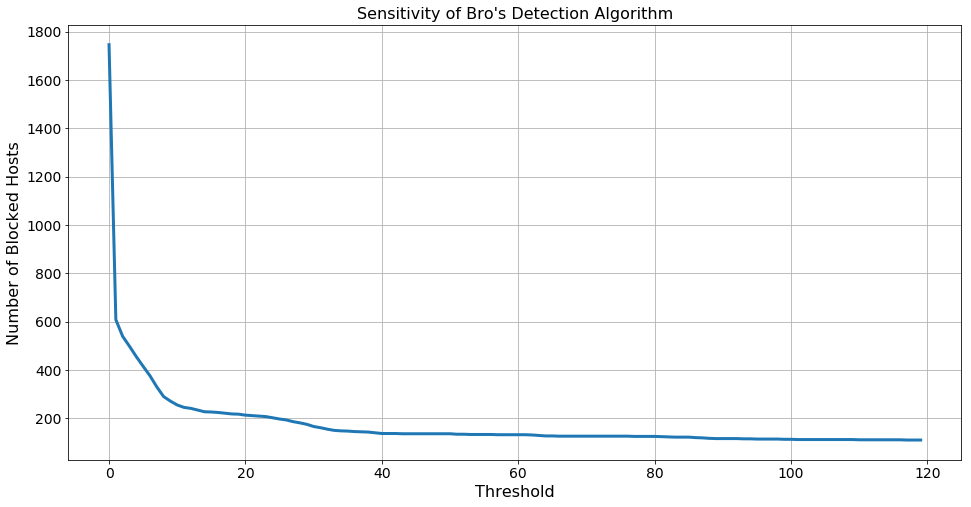

```python
%matplotlib inline
from plotting import plot_bro

# TODO: generate the list described above
block_host_cnt_list=[]

for i in range(1,121):
    block_host_cnt=len(run_bro(i))
    block_host_cnt_list.append(block_host_cnt)

#print(len(run_bro(100)))

# TODO: pass the list to the plot_bro function
plot_bro(block_host_cnt_list)
```

#### Question 3:

A threshold of 100 is the default for Bro's algorithm. Given the results in the above plot, why do you think this value was chosen? What are the pros and cons of choosing a higher or lower threshold?

#### Answer 3:

在Bro算法中，选择阈值的过程通常是基于对网络流量和威胁模式的实际了解和分析。选择默认阈值为100可能是基于对正常网络流量的观察和对恶意活动的典型特征的了解。具体的阈值选择可能取决于许多因素，包括网络规模、流量模式、恶意活动的类型等。

选择更高或更低的阈值都会有一些优缺点：

更高的阈值（例如，200或300）:

优点：减少了误报的可能性，因为需要更多的连接来触发阈值。 缺点：可能会延迟对潜在恶意活动的响应，因为需要更长的时间来积累足够的连接。对于快速传播的威胁，可能不够敏感。 更低的阈值（例如，50或75）:

优点：更敏感，可能更早地检测到一些恶意活动。 缺点：增加了误报的可能性，因为更容易触发阈值。可能会导致对正常活动的过度阻止。 在选择阈值时，需要在准确性和误报之间进行权衡，并考虑到网络的具体情况。对于大型网络和高连接速率的环境，可能需要更高的阈值以减少误报。对于小型网络或者对于更快速检测潜在威胁更为敏感的场景，可能会选择较低的阈值。最佳的阈值选择通常需要通过实验和不断的调整来优化。

#### Question 4:

A threshold of 100 would have blocked $\approx$115 hosts (if your implementation didn't, you should check it for bugs). This is many fewer hosts than the number of malicious hosts found in Part B. What differences between Bro's algorithm and the method usd in Part B caused this difference? Which method do you think is more likely to be accurate? Why?

#### Answer 4:

一个阈值为100的Bro算法阻止了大约115个主机，而这个数量相对较少。相比之下，使用已知的恶意端口进行端口扫描检测找到的恶意主机数量要多得多。

首先，Bro算法是基于设置阈值的概念的。在block_connection方法中，它检查是否达到了指定的阈值，如果达到了则阻止连接。这样的设置可能会导致一些相对正常的行为被误判为恶意，因为一些主机可能具有高连接频率而不一定是恶意的。

而使用已知的恶意端口进行端口扫描检测可能更注重于检测特定的恶意模式，例如扫描活动。这种方法可能更早地识别到一些潜在的威胁，而不依赖于连接数量的阈值。

哪种方法更可能是准确的取决于具体的应用场景和对于恶意活动的特征的了解。如果恶意活动主要通过大量连接来实现，而这些连接很可能是正常的，那么Bro算法的阈值设置可能导致较少的恶意主机被阻止。另一方面，如果已知的恶意端口扫描活动是主要威胁，那么使用特定端口检测可能更为准确。

There are many other online port scan detection algorithms in addition to Bro. For example, the Threshold Random Walk (TRW) algorithm uses maximum likelihood ratios to tune the threshold parameter in an attempt to block as much malicious traffic as possible without blacklisting benign hosts.

If you are curious, the TRW algorithm is described in this paper: http://www.icir.org/vern/papers/portscan-oak04.pdf.

## Submission

**Remember to "Save and Checkpoint" (from the "File" menu above) before you leave the notebook or close your tab.**